# 200811-study

Nougaga

2020 8 11

## **기술통계 분석(Descriptive Statistics)**

기술통계란 자료를 요약하는 기초적인 통계량으로,

데이터 분석 전에 전체적인 데이터 분포의 이해와 통계적 수치를 제공한다.

이를 이용하여 모집단의 특성을 유추해볼 수 있다.

### **1. 빈도 분석**

빈도분석은 설문조사 결과에 대한 가장 기초적인 정보를 제공해주는 분석방법으로 광범위하게 이용된다.

특히 성별이나 직급을 수치화하는 명목척도나 서열척도와 같은 범주형 데이터를 대상으로

비율을 측정하는 데에 주로 이용된다.

### **2. 기술통계 분석**

기술통계 분석은 빈도분석과 유사하지만 등간척도나 비율척도와 같은 연속적 데이터를 분석할 때 주로 이용한다.

명목척도나 서열척도와 같은 범주형 데이터는 수치에 의미가 없기 때문이다.

분포의 특성은 표본의 평균값, 중앙값, 최빈값 등으로 나타내며,

빈도수, 비율, 표준편차, 분산 등으로 표본의 분포를 알 수 있다.

- 대표값: mean, sum, median, mode, quantile
- 산포도: Variance, Standard, Deviation, min/MAX, range
- 비대칭도: 첨도(Kurtosis), 왜도(Skewness)

```r
data <- read.csv("..\\..\\..\\statistics\\descriptive.csv", header=T)
head(data)
```

```
##   resident gender age level cost type survey pass
## 1        1      1  50     1  5.1    1      1    2
## 2        2      1  54     2  4.2    1      2    2
## 3       NA      1  62     2  4.7    1      1    1
## 4        4      2  50    NA  3.5    1      4    1
## 5        5      1  51     1  5.0    1      3    1
## 6        3      1  55     2  5.4    1      3   NA
```

```r
dim(data)
```

```
## [1] 300   8
```

```r
length(data);length(data$survey)
```

```
## [1] 8
```

```
## [1] 300
```

```r
str(data);str(data$survey)
```

```
## 'data.frame':    300 obs. of  8 variables:
##  $ resident: int  1 2 NA 4 5 3 2 5 NA 2 ...
##  $ gender  : int  1 1 1 2 1 1 2 1 1 1 ...
##  $ age     : int  50 54 62 50 51 55 56 49 49 49 ...
##  $ level   : int  1 2 2 NA 1 2 1 2 1 2 ...
##  $ cost    : num  5.1 4.2 4.7 3.5 5 5.4 4.1 675 4.4 4.9 ...
##  $ type    : int  1 1 1 1 1 1 1 NA 1 1 ...
##  $ survey  : int  1 2 1 4 3 3 NA NA NA 1 ...
##  $ pass    : int  2 2 1 1 1 NA 2 2 2 1 ...
```

```
##  int [1:300] 1 2 1 4 3 3 NA NA NA 1 ...
```

#### 데이터 특성(최소/최대, 펴균, 분위수, 노이즈-NA) 제공

```r
summary(data)
```

```
##     resident         gender          age            level
##  Min.   :1.000   Min.   :0.00   Min.   :40.00   Min.   :1.000
##  1st Qu.:1.000   1st Qu.:1.00   1st Qu.:48.00   1st Qu.:1.000
##  Median :2.000   Median :1.00   Median :53.00   Median :2.000
##  Mean   :2.233   Mean   :1.42   Mean   :53.88   Mean   :1.836
##  3rd Qu.:3.000   3rd Qu.:2.00   3rd Qu.:60.00   3rd Qu.:2.000
##  Max.   :5.000   Max.   :5.00   Max.   :69.00   Max.   :3.000
##  NA's   :21                                     NA's   :13
##       cost               type          survey          pass
##  Min.   :-457.200   Min.   :1.00   Min.   :1.00   Min.   :1.000
##  1st Qu.:   4.425   1st Qu.:1.00   1st Qu.:2.00   1st Qu.:1.000
##  Median :   5.400   Median :1.00   Median :3.00   Median :1.000
##  Mean   :   8.752   Mean   :1.27   Mean   :2.61   Mean   :1.432
##  3rd Qu.:   6.300   3rd Qu.:2.00   3rd Qu.:3.00   3rd Qu.:2.000
##  Max.   : 675.000   Max.   :2.00   Max.   :5.00   Max.   :2.000
##  NA's   :30         NA's   :26     NA's   :113    NA's   :20
```

#### **2.1. 명목척도 기술 통계량**

```r
length(data$gender)
```

```
## [1] 300
```

```r
summary(data$gender)  # 딱히 의미없음
```

```
##    Min. 1st Qu.  Median    Mean 3rd Qu.    Max.
##    0.00    1.00    1.00    1.42    2.00    5.00
```

```r
table(data$gender)    # 각 성별 빈도수 - outlier(0,5) 확인
```

```
##
##   0   1   2   5
##   2 173 124   1
```

#### 이상치(outlier) 제거

```
##
##   1   2
## 173 124
```

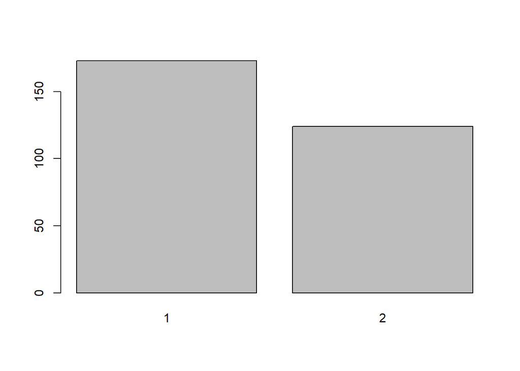

```r
data <- subset(data, data$gender==1 | data$gender==2)  # 성별 outlier 제거
x <- table(data$gender)
x; barplot(x)
```

#### 구성비율 계산: prop.table() -> 명목변수들 간의 구성 비율을 계산

```r
prop.table(x)
```

```
##
##         1         2
## 0.5824916 0.4175084
```

```r
y <- round(prop.table(x)*100, 2)
y
```

```
##
##     1     2
## 58.25 41.75
```

#### **2.2. 서열척도 기술 통계량: ex. 상-중-하**

```r
length(data$level)  # 학력수준 - 서열
```

```
## [1] 297
```

```r
summary(data$level) # 딱히 의미없음
```

```
##    Min. 1st Qu.  Median    Mean 3rd Qu.    Max.    NA's
##   1.000   1.000   2.000   1.842   2.000   3.000      13
```

```r
table(data$level)   # 빈도분석 - 의미있음
```

```
##
##   1   2   3
## 115  99  70
```

#### 변수의 빈도수 시각화

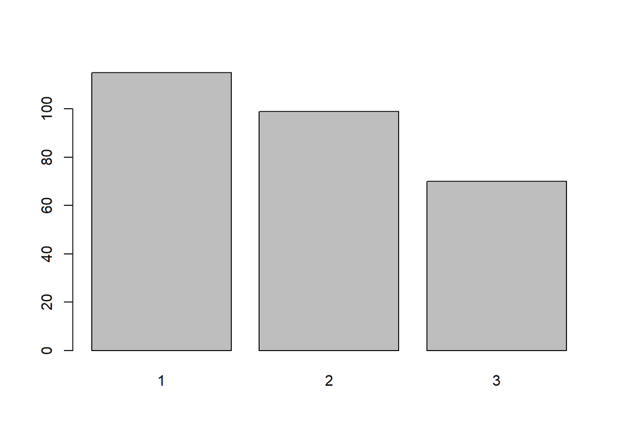

```r
x1 <- table(data$level)
barplot(x1)
```

#### **2.3. 등간척도 기술 통계량 -> 등간격(서열 X)** #### 만족도 변수 대상 요약통계량 구하기

```r
survey <- data$survey
survey
```

```
##   [1]  1  2  1  4  3  3 NA NA NA  1  2  2  2  2 NA NA NA NA NA NA NA  2  2  1  2
##  [26]  3  3  5  2 NA NA NA NA NA NA NA NA NA  2  2  3  4  3  2  2  3  4  5  4  2
##  [51] NA  2  3  4  3 NA NA NA NA NA NA NA  3  3  3  3  2  2  3  3 NA NA NA  2  2
##  [76]  2 NA  2  2  3 NA NA  3  3  3  3  3  3  3  1  4 NA NA NA NA  4  3  3  4 NA
## [101] NA NA NA  3  3  2 NA NA  3 NA  2 NA  2  2  5  2 NA  3 NA NA NA NA NA NA NA
## [126] NA NA NA  2  2  4  3  4  3  3  3 NA NA NA  2  2  2  2  2  1  2 NA NA NA NA
## [151] NA  3  3  3  3  4  3 NA  4  2  2  2  2  2 NA NA NA NA  3  3  2 NA  2  3  3
## [176]  3 NA NA  3  4  3  4 NA NA  3  3  4  2  1  2  4  3  3  2  5  2  2  2  2  1
## [201]  2  4 NA  2  2  1  1  1  2  2 NA NA NA NA NA NA NA NA NA NA  2  3  4  5  3
## [226]  3  4 NA  2  1  2 NA  1  2  2  1  2  2 NA NA  3  4  5  3 NA  3  4  4  5  2
## [251]  2  3 NA NA  2  1  2  1 NA NA  2  3 NA  3  4  3  4  3  4 NA NA NA  2  1  2
## [276] NA NA NA NA NA  1  1  2  2 NA NA NA NA NA  2  1  2  3 NA NA NA NA
```

```r
summary(survey) # 만족도(5점 척도)인 경우 의미있음 -> 2.6(평균이상)
```

```
##    Min. 1st Qu.  Median    Mean 3rd Qu.    Max.    NA's
##   1.000   2.000   3.000   2.605   3.000   5.000     112
```

```r
x1 <- table(survey)
x1
```

```
## survey
##  1  2  3  4  5
## 20 72 61 25  7
```

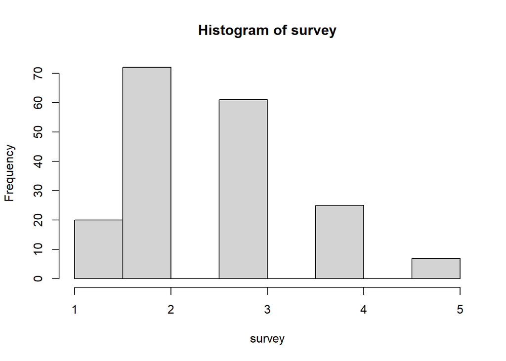

```r
hist(survey)
```

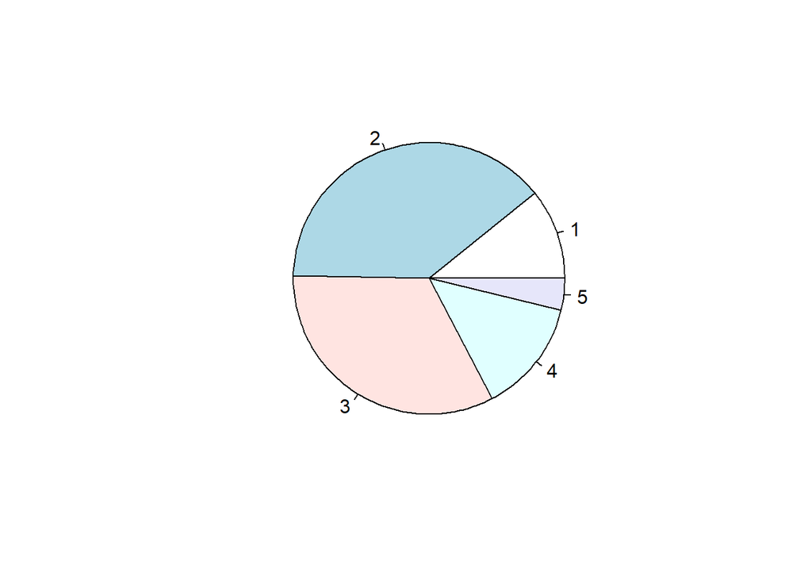

```r
pie(x1)
```

#### **2.4. 비율척도 기술 통계량** #### 생활비 변수 대상 요약 통계량 구하기

```r
length(data$cost)
```

```
## [1] 297
```

```r
summary(data$cost)  # 요약통계량 - 의미있음(mean=8.784)
```

```
##     Min.  1st Qu.   Median     Mean  3rd Qu.     Max.     NA's
## -457.200    4.400    5.400    8.784    6.300  675.000       30
```

#### 데이터 정제(결측치 제거)

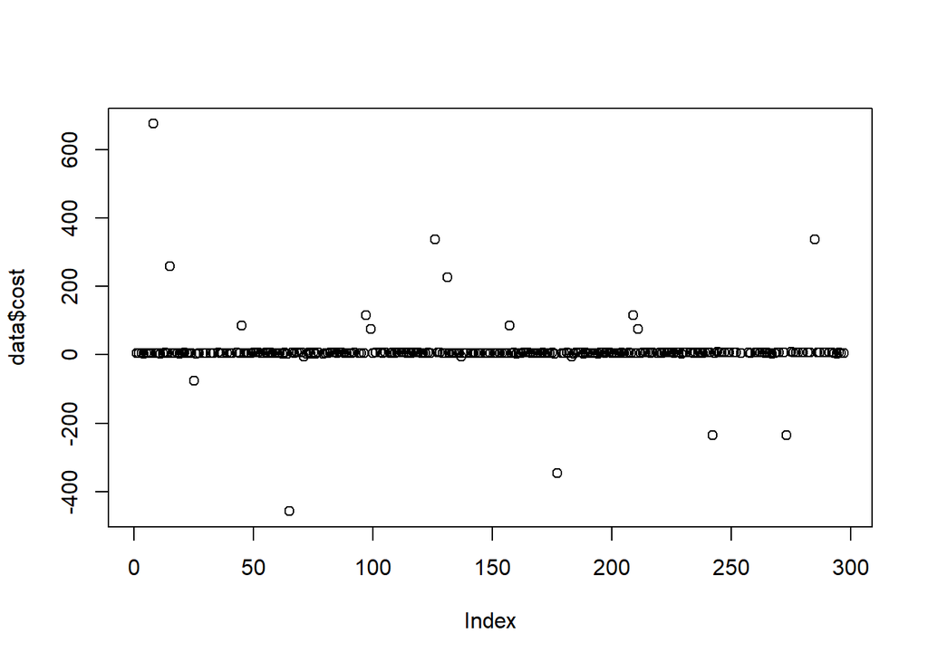

```r
plot(data$cost)
```

```r
data <- subset(data, data$cost >=2 & data$cost <= 10) # 총점기준
data
```

```
##     resident gender age level cost type survey pass
## 1          1      1  50     1  5.1    1      1    2
## 2          2      1  54     2  4.2    1      2    2
## 3         NA      1  62     2  4.7    1      1    1
## 4          4      2  50    NA  3.5    1      4    1
## 5          5      1  51     1  5.0    1      3    1
## 6          3      1  55     2  5.4    1      3   NA
## 7          2      2  56     1  4.1    1     NA    2
## 9         NA      1  49     1  4.4    1     NA    2
## 10         2      1  49     2  4.9    1      1    1
## 11         5      2  49    NA  2.3    1      2    1
## 12         3      1  52     1  4.2    1      2    2
## 13         1      1  57     1  6.7    1      2    1
## 14         2      2  51     3  4.3    1      2    1
## 16         1      1  63     1  5.7    1     NA    2
```

[output cut: 234 more lines]

```r
x <- data$cost
mean(x)
```

```
## [1] 5.354032
```

#### 평균이 극단치에 영향을 받는 경우 중위수로 대체

```r
median(x) # 5.4
```

```
## [1] 5.4
```

#### **(1) 대표값 구하기**

#### 생활비(cost) 변수 대상 대표값 구하기

```r
mean(x)
```

```
## [1] 5.354032
```

```r
median(x)
```

```
## [1] 5.4
```

```r
sort(x)               # 오름차순(default)
```

```
##   [1] 2.1 2.3 2.3 3.0 3.0 3.0 3.0 3.0 3.0 3.3 3.3 3.4 3.4 3.5 3.5 3.5 3.5 3.5
##  [19] 3.8 3.8 3.8 3.9 3.9 3.9 4.0 4.0 4.0 4.0 4.0 4.0 4.0 4.0 4.0 4.0 4.0 4.0
##  [37] 4.0 4.0 4.0 4.1 4.1 4.1 4.1 4.1 4.1 4.1 4.1 4.1 4.2 4.2 4.2 4.3 4.3 4.3
##  [55] 4.3 4.3 4.4 4.4 4.4 4.4 4.5 4.6 4.6 4.6 4.6 4.6 4.7 4.7 4.7 4.7 4.7 4.7
##  [73] 4.8 4.8 4.9 4.9 4.9 4.9 5.0 5.0 5.0 5.0 5.0 5.0 5.0 5.0 5.0 5.0 5.0 5.0
##  [91] 5.0 5.0 5.0 5.0 5.0 5.0 5.1 5.1 5.1 5.1 5.1 5.1 5.1 5.1 5.1 5.1 5.2 5.2
## [109] 5.2 5.2 5.2 5.2 5.2 5.2 5.2 5.3 5.3 5.3 5.3 5.3 5.3 5.3 5.4 5.4 5.4 5.4
## [127] 5.4 5.5 5.5 5.5 5.5 5.5 5.5 5.5 5.5 5.6 5.6 5.6 5.6 5.7 5.7 5.7 5.7 5.7
## [145] 5.7 5.8 5.8 5.8 5.8 5.8 5.9 5.9 6.0 6.0 6.0 6.0 6.0 6.0 6.0 6.0 6.0 6.0
## [163] 6.0 6.0 6.0 6.0 6.1 6.1 6.1 6.1 6.1 6.1 6.1 6.1 6.2 6.2 6.2 6.2 6.2 6.2
## [181] 6.2 6.2 6.2 6.2 6.2 6.2 6.2 6.3 6.3 6.3 6.3 6.3 6.3 6.3 6.3 6.3 6.3 6.3
## [199] 6.3 6.3 6.3 6.3 6.3 6.4 6.4 6.4 6.4 6.4 6.4 6.4 6.4 6.4 6.4 6.4 6.5 6.5
## [217] 6.5 6.5 6.7 6.7 6.7 6.7 6.7 6.7 6.7 6.7 6.8 6.8 6.8 6.8 6.9 6.9 6.9 6.9
## [235] 7.0 7.0 7.0 7.1 7.1 7.1 7.2 7.2 7.7 7.7 7.7 7.7 7.9 7.9
```

```r
sort(x, decreasing=T) # 내림차순
```

```
##   [1] 7.9 7.9 7.7 7.7 7.7 7.7 7.2 7.2 7.1 7.1 7.1 7.0 7.0 7.0 6.9 6.9 6.9 6.9
##  [19] 6.8 6.8 6.8 6.8 6.7 6.7 6.7 6.7 6.7 6.7 6.7 6.7 6.5 6.5 6.5 6.5 6.4 6.4
##  [37] 6.4 6.4 6.4 6.4 6.4 6.4 6.4 6.4 6.4 6.3 6.3 6.3 6.3 6.3 6.3 6.3 6.3 6.3
##  [55] 6.3 6.3 6.3 6.3 6.3 6.3 6.3 6.2 6.2 6.2 6.2 6.2 6.2 6.2 6.2 6.2 6.2 6.2
##  [73] 6.2 6.2 6.1 6.1 6.1 6.1 6.1 6.1 6.1 6.1 6.0 6.0 6.0 6.0 6.0 6.0 6.0 6.0
##  [91] 6.0 6.0 6.0 6.0 6.0 6.0 5.9 5.9 5.8 5.8 5.8 5.8 5.8 5.7 5.7 5.7 5.7 5.7
## [109] 5.7 5.6 5.6 5.6 5.6 5.5 5.5 5.5 5.5 5.5 5.5 5.5 5.5 5.4 5.4 5.4 5.4 5.4
## [127] 5.3 5.3 5.3 5.3 5.3 5.3 5.3 5.2 5.2 5.2 5.2 5.2 5.2 5.2 5.2 5.2 5.1 5.1
## [145] 5.1 5.1 5.1 5.1 5.1 5.1 5.1 5.1 5.0 5.0 5.0 5.0 5.0 5.0 5.0 5.0 5.0 5.0
## [163] 5.0 5.0 5.0 5.0 5.0 5.0 5.0 5.0 4.9 4.9 4.9 4.9 4.8 4.8 4.7 4.7 4.7 4.7
## [181] 4.7 4.7 4.6 4.6 4.6 4.6 4.6 4.5 4.4 4.4 4.4 4.4 4.3 4.3 4.3 4.3 4.3 4.2
## [199] 4.2 4.2 4.1 4.1 4.1 4.1 4.1 4.1 4.1 4.1 4.1 4.0 4.0 4.0 4.0 4.0 4.0 4.0
## [217] 4.0 4.0 4.0 4.0 4.0 4.0 4.0 4.0 3.9 3.9 3.9 3.8 3.8 3.8 3.5 3.5 3.5 3.5
## [235] 3.5 3.4 3.4 3.3 3.3 3.0 3.0 3.0 3.0 3.0 3.0 2.3 2.3 2.1
```

#### 생활비(cost) 변수 대상 사분위수 구하기

```r
quantile(x, 1/4)
```

```
## 25%
## 4.6
```

```r
quantile(x, 2/4)
```

```
## 50%
## 5.4
```

```r
quantile(x, 3/4)
```

```
## 75%
## 6.2
```

```r
quantile(x, 4/4)
```

```
## 100%
##  7.9
```

#### **(2) 산포도 구하기**

#### 생활비(cost) 변수 대상 산포도 구하기

```r
var(x)
```

```
## [1] 1.296826
```

```r
sd(x)
```

```
## [1] 1.138783
```

```r
sqrt(var(x))
```

```
## [1] 1.138783
```

```r
sd(x)^2
```

```
## [1] 1.296826
```

#### **(3) 표본분산과 표본 표준편차**

#### **(4) 빈도분석**

#### 생활비(cost) 변수의 빈도분석과 시각화

```r
table(data$cost)
```

```
##
## 2.1 2.3   3 3.3 3.4 3.5 3.8 3.9   4 4.1 4.2 4.3 4.4 4.5 4.6 4.7 4.8 4.9   5 5.1
##   1   2   6   2   2   5   3   3  15   9   3   5   4   1   5   6   2   4  18  10
## 5.2 5.3 5.4 5.5 5.6 5.7 5.8 5.9   6 6.1 6.2 6.3 6.4 6.5 6.7 6.8 6.9   7 7.1 7.2
##   9   7   5   8   4   6   5   2  14   8  13  16  11   4   8   4   4   3   3   2
## 7.7 7.9
##   4   2
```

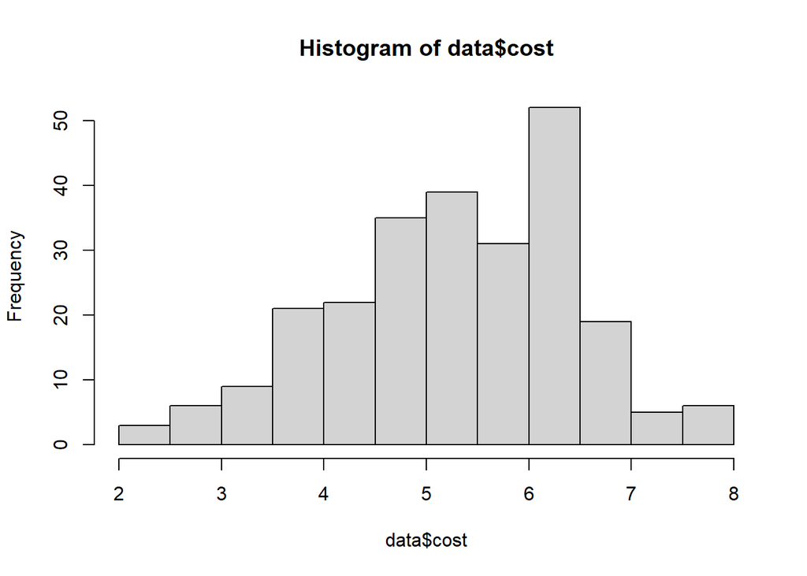

```r
hist(data$cost) # 히스토그램 시각화
```

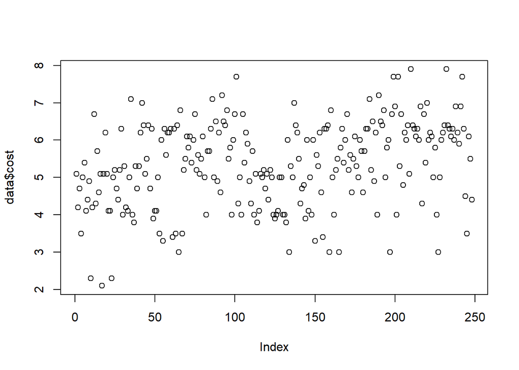

```r
plot(data$cost) # 산점도 시각화화
```

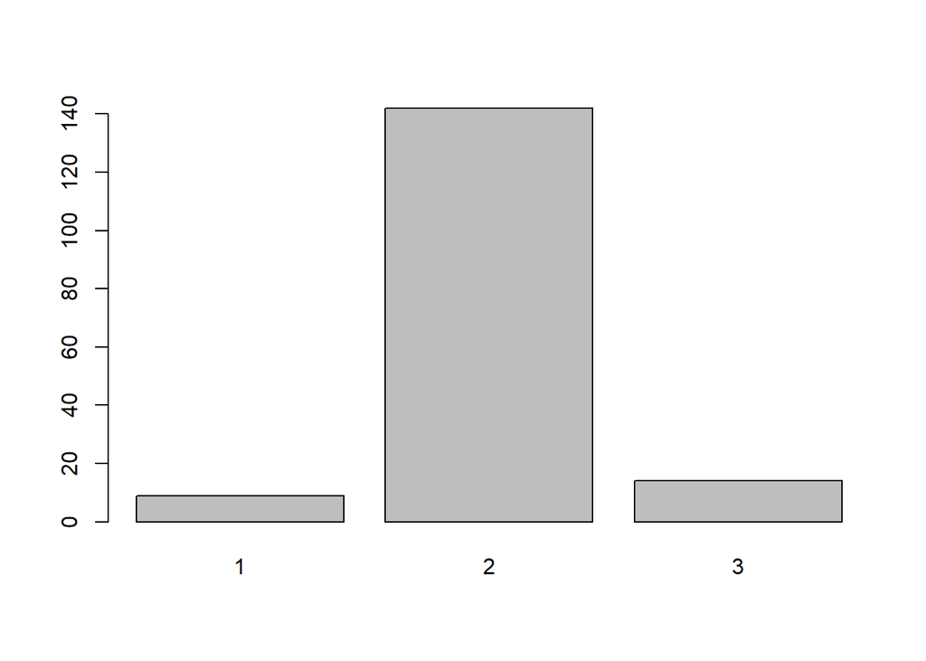

```r
data$cost2[data$cost >=1 & data$cost <=3] <- 1
data$cost2[data$cost >=4 & data$cost <=6] <- 2
data$cost2[data$cost >=7] <- 3

tbl_cost2 <- table(data$cost2)
barplot(tbl_cost2)
```

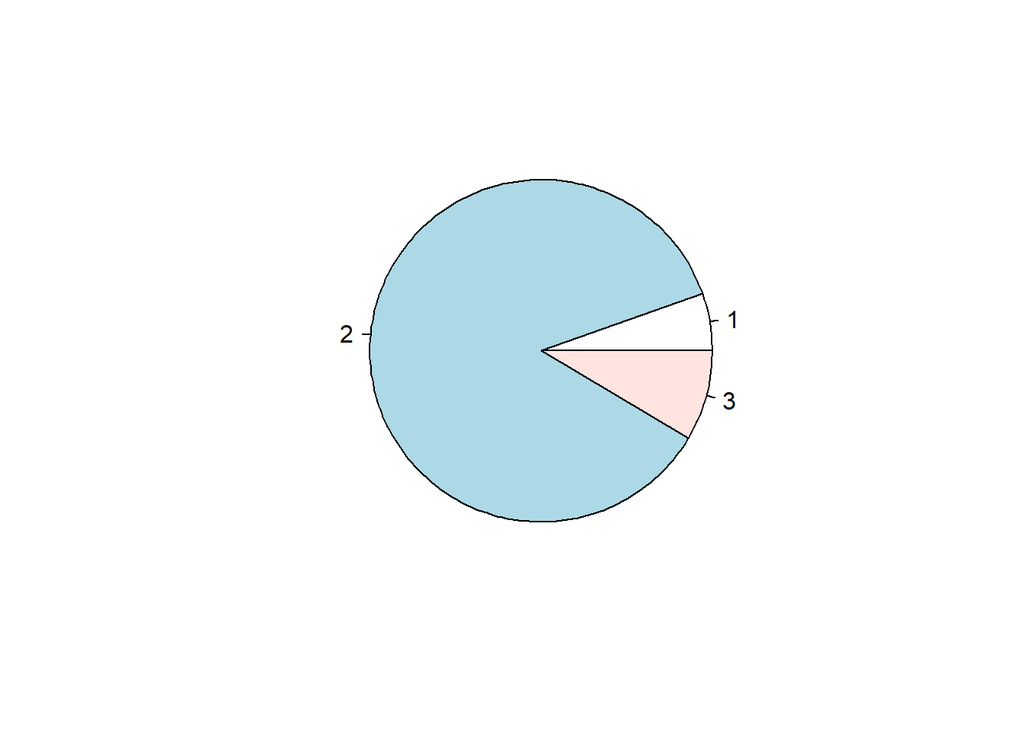

```r
pie(tbl_cost2)
```

#### **2.5. 비대칭도 구하기기**

```r
library(moments)
cost <- data$cost   # 정제된 data
cost
```

```
##   [1] 5.1 4.2 4.7 3.5 5.0 5.4 4.1 4.4 4.9 2.3 4.2 6.7 4.3 5.7 4.6 5.1 2.1 5.1
##  [19] 6.2 5.1 4.1 4.1 2.3 5.0 5.2 4.7 4.4 5.2 6.3 4.0 5.3 4.2 4.1 5.0 7.1 4.0
##  [37] 3.8 5.3 4.7 5.3 6.2 7.0 6.4 5.1 5.5 6.4 4.7 6.3 3.9 4.1 4.1 5.0 3.5 6.0
##  [55] 3.3 6.3 5.6 6.2 6.2 6.3 3.4 6.3 3.5 6.4 3.0 6.8 3.5 5.2 5.5 6.1 5.8 6.1
##  [73] 5.4 6.0 6.7 5.2 5.6 5.1 5.5 6.1 5.0 4.0 5.7 5.7 6.3 7.1 5.0 6.5 4.9 6.2
##  [91] 4.6 7.2 6.5 6.4 6.8 5.5 5.8 4.0 6.0 6.7 7.7 4.3 5.0 4.0 6.7 5.4 6.2 5.9
## [109] 4.9 4.3 5.7 4.0 5.1 3.8 4.1 5.1 5.0 5.2 4.7 5.1 4.4 5.2 5.0 4.0 3.9 4.0
## [127] 4.1 5.0 5.0 4.0 4.0 3.8 6.0 3.0 5.3 5.0 7.0 6.4 6.2 5.5 4.3 4.7 4.8 3.9
## [145] 6.0 4.1 5.0 4.0 6.0 3.3 5.6 5.3 6.2 4.6 3.4 6.3 6.3 6.4 3.0 6.8 5.0 4.0
## [163] 5.2 5.5 3.0 5.8 6.3 5.4 6.0 6.7 5.2 5.6 4.6 5.5 6.1 5.3 5.0 6.0 5.7 4.6
## [181] 5.7 6.3 6.3 7.1 5.2 6.5 4.9 6.2 4.0 7.2 6.5 6.4 6.8 5.0 5.8 6.0 3.0 6.7
## [199] 7.7 6.9 4.0 7.7 5.3 6.7 4.8 6.2 6.0 6.4 5.1 7.9 6.4 6.3 6.1 6.3 6.0 6.9
## [217] 4.3 6.7 5.4 7.0 6.0 6.2 6.1 5.0 5.8 4.0 3.0 5.0 6.0 6.2 6.4 7.9 6.4 6.3
## [235] 6.1 6.3 6.0 6.9 6.2 5.9 6.9 7.7 6.3 4.5 3.5 6.1 5.5 4.4
```

```r
# 왜도 - 평균을 중심으로 기울어진 정도
skewness(cost)
```

```
## [1] -0.297234
```

```r
# 첨도 - 표준정규분포와 비교하여 얼마나 뾰족한가 측정 지표
kurtosis(cost)
```

```
## [1] 2.674163
```

#### 히스토그램 확률밀도/표준정규분포 곡선

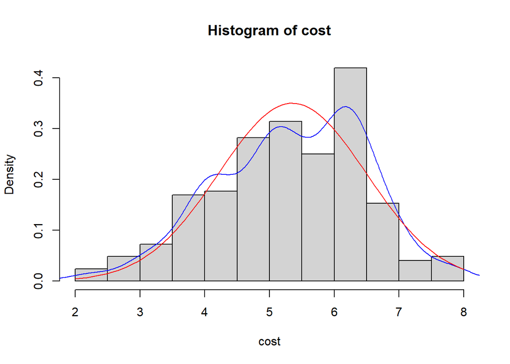

```r
hist(cost, freq = F)

# 확률밀도 분포 곡선
lines(density(cost), col="blue")

# 표준정규분포 곡선
x <- seq(0, 8, 0.1)
curve(dnorm(x, mean(cost), sd(cost)), col="red", add=T)
```

```r
# ?dbinom # 이항분포
# 성공확률 90%일 때, 3회 시행 시 0번 성공할 확률
dbinom(0,3,0.9)
```

```
## [1] 0.001
```

```r
# 성공확률 90%일 때, 3회 시행 시 3번 성공할 확률
dbinom(3,3,0.9)
```

```
## [1] 0.729
```

```r
# 확률분포표 확인
n = 3
result <- numeric()
for (i in 0:n){
  cat(i,"번 성공 확률: ", dbinom(i, 3, 0.9), "\n", sep="")
  result <- append(result, dbinom(i, 3, 0.9))
}
```

```
## 0번 성공 확률: 0.001
## 1번 성공 확률: 0.027
## 2번 성공 확률: 0.243
## 3번 성공 확률: 0.729
```

```r
result
```

```
## [1] 0.001 0.027 0.243 0.729
```

```r
# 1. 5지선다인 20문항의 시험에서 랜덤하게 답안을 고를 경우 다음의 확률은 어떻게 되겠는가?
n = 20
p = 1/5

# 1) 다 틀릴 확률
dbinom(0, n, p)
```

```
## [1] 0.01152922
```

```r
# 2) 8개 이상 맞출 확률
sum(dbinom(8:n, n, p))
```

```
## [1] 0.03214266
```

```r
# 2. CEO에게 해당 블라인드 테스트 진행을 제안하자, CEO는 100명 중 최소 40명이
# 맥주를 맞힐 확률이 95% 이상이라면 $170M을 기꺼이 투자하겠다고 밝혔다.
# 이 기획을 서포트 하기 위해 R을 이용해 확률을 구해보세요.
# (단, 테스트 진행 표본수(n)과 성공횟수(k)를 변동시키며 값을 확인 할 수 있도록 UDF로 구현해보세요)

f <- function(n, k){
  return(sum(dbinom(k:n, n, 0.5)))
}

p = f(100, 40)
if (p >= 0.95){
  print("투자O.")
}else{
  print("투자X")
}
```

```
## [1] "투자O."
```

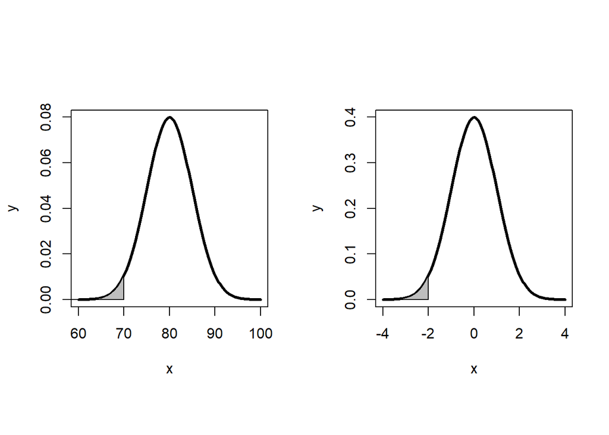

```r
# 3. 신입사원 문제 표준정규분포도 작성
# pnorm(70, 80, 5) = 0.02275
# qnorm(0.02275, 80, 5) = 69.99999
par(mfrow = c(1, 2), pty = "s")

x=seq(60, 100, length=100)
y=dnorm(x, 80, 5)
plot(x,y,type="l", lwd=3)
x=seq(0, 70, length=100)
y=dnorm(x, 80, 5)
polygon(c(60,x,70), c(0,y,0), col="gray")

z = (70-80)/5
x=seq(-4, 4, length=100)
y=dnorm(x)
plot(x,y,type="l", lwd=3)
x=seq(-4, z, length=100)
y=dnorm(x)
polygon(c(-4, x, z), c(0, y, 0), col="gray")
```